# CITS4009 project1

Haitian Wang

2023-09-03

# 1. Introduction:

The dataset at hand, titled “Global YouTube Statistics 2023,” originates from Kaggle, a renowned platform for data science projects and competitions. The data was meticulously collected by Nidula Elgiriyewithana. For those unfamiliar, Kaggle serves as a hub where data enthusiasts and professionals alike can share datasets, participate in challenges, and contribute to a wealth of shared knowledge in the field of data science.

The “Global YouTube Statistics 2023” dataset provides a comprehensive overview of various YouTube channels, shedding light on key metrics such as the number of subscribers, video views, earnings, and more. With information spanning categories, countries, and other diverse facets, the dataset serves as a significant tool to understand the dynamics of YouTube content creation, viewership patterns, and the emerging trends in digital content consumption. Moreover, with details on the country, it allows for cross-cultural comparisons and insights into regional content preferences.

# 2. Data loading, Overview and Set up

This section lays the foundational steps for any subsequent data analysis operations. Before we can derive any meaningful insights from the data, we need to perform a series of initial processes. These processes not only involve loading the data into our working environment but also familiarizing ourselves with its structure, content, and peculiarities. This foundational knowledge allows us to effectively maneuver through the data, understand its intricacies, and set up the stage for more advanced analyses

## 2.1 Load libraries

```r
library(tidyverse)
library(lubridate)
library(gridExtra)
library(reshape2)
library(grid)
```

## 2.2 Main Data Loading

```r
data.path <- './Global_YouTube_Statistics.csv'
youtube_data <- read.csv(data.path)
```

## 2.3 Plotting Theme setting

```r
custom_youtube_theme <- function() {
  theme_minimal(base_size = 12) +
    theme(
      plot.title = element_text(color = "#3366CC", face = "bold", size = 16),
      axis.title = element_text(color = "#666666"),
      axis.text = element_text(color = "#333333"),
      panel.grid.major = element_line(color = "#DDDDDD"),
      panel.grid.minor = element_blank(),
      strip.text.x = element_text(size = 12, colour = "#444444", face = "italic"),
      plot.margin = margin(20, 40, 20, 40)
    )
}
```

## 2.4 Analyze the data structure

```r
str(youtube_data)
```

```
## 'data.frame':    995 obs. of  28 variables:
##  $ rank                                   : int  1 2 3 4 5 6 7 8 9 10 ...
##  $ Youtuber                               : chr  "T-Series" "YouTube Movies" "MrBeast" "Cocomelon - Nursery Rhymes" ...
##  $ subscribers                            : int  245000000 170000000 166000000 162000000 159000000 119000000 112000000 111000000 106000000 98900000 ...
##  $ video.views                            : num  2.28e+11 0.00 2.84e+10 1.64e+11 1.48e+11 ...
##  $ category                               : chr  "Music" "Film & Animation" "Entertainment" "Education" ...
##  $ Title                                  : chr  "T-Series" "youtubemovies" "MrBeast" "Cocomelon - Nursery Rhymes" ...
##  $ uploads                                : int  20082 1 741 966 116536 0 1111 4716 493 574 ...
##  $ Country                                : chr  "India" "United States" "United States" "United States" ...
##  $ Abbreviation                           : chr  "IN" "US" "US" "US" ...
##  $ channel_type                           : chr  "Music" "Games" "Entertainment" "Education" ...
##  $ video_views_rank                       : int  1 4055159 48 2 3 4057944 5 44 630 8 ...
##  $ country_rank                           : num  1 7670 1 2 2 NaN 3 1 5 5 ...
##  $ channel_type_rank                      : num  1 7423 1 1 2 ...
##  $ video_views_for_the_last_30_days       : num  2.26e+09 1.20e+01 1.35e+09 1.98e+09 1.82e+09 ...
##  $ lowest_monthly_earnings                : num  564600 0 337000 493800 455900 ...
##  $ highest_monthly_earnings               : num  9.0e+06 5.0e-02 5.4e+06 7.9e+06 7.3e+06 ...
##  $ lowest_yearly_earnings                 : num  6.8e+06 4.0e-02 4.0e+06 5.9e+06 5.5e+06 ...
##  $ highest_yearly_earnings                : num  1.08e+08 5.80e-01 6.47e+07 9.48e+07 8.75e+07 ...
##  $ subscribers_for_last_30_days           : num  2e+06 NaN 8e+06 1e+06 1e+06 NaN NaN NaN 1e+05 6e+05 ...
##  $ created_year                           : num  2006 2006 2012 2006 2006 ...
##  $ created_month                          : chr  "Mar" "Mar" "Feb" "Sep" ...
##  $ created_date                           : num  13 5 20 1 20 24 12 29 14 23 ...
##  $ Gross.tertiary.education.enrollment....: num  28.1 88.2 88.2 88.2 28.1 NaN 88.2 63.2 81.9 88.2 ...
##  $ Population                             : num  1.37e+09 3.28e+08 3.28e+08 3.28e+08 1.37e+09 ...
##  $ Unemployment.rate                      : num  5.36 14.7 14.7 14.7 5.36 NaN 14.7 2.29 4.59 14.7 ...
##  $ Urban_population                       : num  4.71e+08 2.71e+08 2.71e+08 2.71e+08 4.71e+08 ...
##  $ Latitude                               : num  20.6 37.1 37.1 37.1 20.6 ...
##  $ Longitude                              : num  79 -95.7 -95.7 -95.7 79 ...
```

The dataset is a data frame containing 995 observations and 28 variables. The variables contain different types of data: integers (int), character strings (chr), and numeric values (num). Several columns like “Youtuber”, “category”, “Title”, “Country”, “Abbreviation”, “channel_type”, and “created_month” are character strings which might be more appropriately treated as factors depending on the analysis. R treats string data as character by default, but they can be converted to factors if they have categories. Columns such as “rank”, “subscribers”, “uploads”, and others are numerical (either integer or numeric).

## 2.5 Analyze the data Summary

```r
summary(youtube_data)
```

```
##       rank         Youtuber          subscribers         video.views
##  Min.   :  1.0   Length:995         Min.   : 12300000   Min.   :0.000e+00
##  1st Qu.:249.5   Class :character   1st Qu.: 14500000   1st Qu.:4.288e+09
##  Median :498.0   Mode  :character   Median : 17700000   Median :7.761e+09
##  Mean   :498.0                      Mean   : 22982412   Mean   :1.104e+10
##  3rd Qu.:746.5                      3rd Qu.: 24600000   3rd Qu.:1.355e+10
##  Max.   :995.0                      Max.   :245000000   Max.   :2.280e+11
##
##    category            Title              uploads           Country
##  Length:995         Length:995         Min.   :     0.0   Length:995
##  Class :character   Class :character   1st Qu.:   194.5   Class :character
##  Mode  :character   Mode  :character   Median :   729.0   Mode  :character
##                                        Mean   :  9187.1
##                                        3rd Qu.:  2667.5
##                                        Max.   :301308.0
##
##  Abbreviation       channel_type       video_views_rank   country_rank
##  Length:995         Length:995         Min.   :      1   Min.   :   1.0
##  Class :character   Class :character   1st Qu.:    323   1st Qu.:  11.0
##  Mode  :character   Mode  :character   Median :    916   Median :  51.0
##                                        Mean   : 554249   Mean   : 386.1
##                                        3rd Qu.:   3584   3rd Qu.: 123.0
##                                        Max.   :4057944   Max.   :7741.0
##                                        NA's   :1         NA's   :116
##  channel_type_rank video_views_for_the_last_30_days lowest_monthly_earnings
##  Min.   :   1.0    Min.   :1.000e+00                Min.   :     0
##  1st Qu.:  27.0    1st Qu.:2.014e+07                1st Qu.:  2700
##  Median :  65.5    Median :6.408e+07                Median : 13300
##  Mean   : 745.7    Mean   :1.756e+08                Mean   : 36886
##  3rd Qu.: 139.8    3rd Qu.:1.688e+08                3rd Qu.: 37900
##  Max.   :7741.0    Max.   :6.589e+09                Max.   :850900
##  NA's   :33        NA's   :56
##  highest_monthly_earnings lowest_yearly_earnings highest_yearly_earnings
##  Min.   :       0         Min.   :       0       Min.   :        0
##  1st Qu.:   43500         1st Qu.:   32650       1st Qu.:   521750
##  Median :  212700         Median :  159500       Median :  2600000
##  Mean   :  589808         Mean   :  442257       Mean   :  7081814
##  3rd Qu.:  606800         3rd Qu.:  455100       3rd Qu.:  7300000
##  Max.   :13600000         Max.   :10200000       Max.   :163400000
##
```

[output cut: 9 more lines]

```
##  Min.   :  7.60                          Min.   :2.025e+05   Min.   : 0.750
##  1st Qu.: 36.30                          1st Qu.:8.336e+07   1st Qu.: 5.270
##  Median : 68.00                          Median :3.282e+08   Median : 9.365
##  Mean   : 63.63                          Mean   :4.304e+08   Mean   : 9.279
##  3rd Qu.: 88.20                          3rd Qu.:3.282e+08   3rd Qu.:14.700
##  Max.   :113.10                          Max.   :1.398e+09   Max.   :14.720
##  NA's   :123                             NA's   :123         NA's   :123
##  Urban_population       Latitude        Longitude
##  Min.   :    35588   Min.   :-38.42   Min.   :-172.10
##  1st Qu.: 55908316   1st Qu.: 20.59   1st Qu.: -95.71
##  Median :270663028   Median : 37.09   Median : -51.93
##  Mean   :224214982   Mean   : 26.63   Mean   : -14.13
##  3rd Qu.:270663028   3rd Qu.: 37.09   3rd Qu.:  78.96
##  Max.   :842933962   Max.   : 61.92   Max.   : 138.25
##  NA's   :123         NA's   :123      NA's   :123
```

## 2.6 Analyze the first few rows of dataset

```r
head(youtube_data)
```

```
##   rank                   Youtuber subscribers  video.views         category
## 1    1                   T-Series   245000000 228000000000            Music
## 2    2             YouTube Movies   170000000            0 Film & Animation
## 3    3                    MrBeast   166000000  28368841870    Entertainment
## 4    4 Cocomelon - Nursery Rhymes   162000000 164000000000        Education
## 5    5                  SET India   159000000 148000000000            Shows
## 6    6                      Music   119000000            0              nan
##                        Title uploads       Country Abbreviation  channel_type
## 1                   T-Series   20082         India           IN         Music
## 2              youtubemovies       1 United States           US         Games
## 3                    MrBeast     741 United States           US Entertainment
## 4 Cocomelon - Nursery Rhymes     966 United States           US     Education
## 5                  SET India  116536         India           IN Entertainment
## 6                      Music       0           nan          nan         Music
##   video_views_rank country_rank channel_type_rank
```

[output cut: 41 more lines]

# 3. Data clean and Initial transformations

## 3.1 Convert string columns

```r
youtube_data$Youtuber <- as.character(youtube_data$Youtuber)
youtube_data$Title <- as.character(youtube_data$Title)
```

## 3.2 Convert factor columns

```r
youtube_data$Country <- as.factor(youtube_data$Country)
youtube_data$channel_type <- as.factor(youtube_data$channel_type)
```

## 3.3 Identify numeric and non-numeric columns

```r
numeric_columns <- names(youtube_data)[sapply(youtube_data, is.numeric)]

non_numeric_columns <- names(youtube_data)[!sapply(youtube_data, is.numeric)]

non_numeric_columns <- setdiff(non_numeric_columns, c("Youtuber", "Title"))
```

## 3.4 # Replace infinite values in numeric columns with their median

```r
for (column_name in numeric_columns) {

  median_value <- median(youtube_data[[column_name]][is.finite(youtube_data[[column_name]])], na.rm = TRUE)

  youtube_data[[column_name]][!is.finite(youtube_data[[column_name]])] <- median_value
}
```

## 3.5 Convert month names to numbers and Create combined date column

```r
month_lookup <- c(Jan=1, Feb=2, Mar=3, Apr=4, May=5, Jun=6, Jul=7, Aug=8, Sep=9, Oct=10, Nov=11, Dec=12)

youtube_data$created_month_num <- as.integer(month_lookup[youtube_data$created_month])

youtube_data$combined_created_date <- with(youtube_data,
                                           ifelse(!is.na(created_year) & !is.na(created_month_num) & !is.na(created_date),
                                                  as.Date(paste(created_year, created_month_num, created_date, sep="-"), format="%Y-%m-%d"),
                                                  NA))
```

## 3.6. Replace na or other values with NA

```r
youtube_data[youtube_data == "nan"] <- NA
youtube_data[youtube_data == "NaN"] <- NA
```

## 3.7 Replace 0 views and uploads with their respective means

```r
youtube_data$video.views[youtube_data$video.views == 0] <- mean(youtube_data$video.views[youtube_data$video.views > 0], na.rm = TRUE)
youtube_data$uploads[youtube_data$uploads == 0] <- mean(youtube_data$uploads[youtube_data$uploads > 0], na.rm = TRUE)
```

## 3.8 Clean negative values in highest_monthly_earnings column

```r
min_positive_earning <- min(youtube_data$highest_monthly_earnings[youtube_data$highest_monthly_earnings > 0], na.rm = TRUE)
youtube_data$highest_monthly_earnings[youtube_data$highest_monthly_earnings <= 0] <- min_positive_earning
```

## 3.9 Replace NA values in numeric columns with median

```r
for (column_name in numeric_columns) {

  median_value <- median(youtube_data[[column_name]], na.rm = TRUE)

  youtube_data[[column_name]][is.na(youtube_data[[column_name]])] <- median_value

}
```

## 3.10 Check missing data count

```r
na_counts <- apply(is.na(youtube_data), 2, sum)
print(na_counts)
```

```
##                                    rank                                Youtuber
##                                       0                                       0
##                             subscribers                             video.views
##                                       0                                       0
##                                category                                   Title
##                                      46                                       0
##                                 uploads                                 Country
##                                       0                                     122
##                            Abbreviation                            channel_type
##                                     122                                      30
##                        video_views_rank                            country_rank
##                                       0                                       0
##                       channel_type_rank        video_views_for_the_last_30_days
##                                       0                                       0
##                 lowest_monthly_earnings                highest_monthly_earnings
##                                       0                                       0
##                  lowest_yearly_earnings                 highest_yearly_earnings
##                                       0                                       0
##            subscribers_for_last_30_days                            created_year
##                                       0                                       0
##                           created_month                            created_date
##                                       5                                       0
## Gross.tertiary.education.enrollment....                              Population
##                                       0                                       0
##                       Unemployment.rate                        Urban_population
##                                       0                                       0
##                                Latitude                               Longitude
##                                       0                                       0
##                       created_month_num                   combined_created_date
##                                       5                                       5
```

## 3.11 Determine median views for segmentation

```r
median_views <- median(youtube_data$video_views, na.rm = TRUE)
```

## 3.12 Segment the data based on median views

```r
high_views <- youtube_data[youtube_data$video_views > median_views, ]
low_views <- youtube_data[youtube_data$video_views <= median_views & !is.na(youtube_data$video_views), ]
```

## 3.12 Analyze missing data in each segment

```r
na_high_views <- apply(is.na(high_views), 2, sum)
na_low_views <- apply(is.na(low_views), 2, sum)
```

# 4. Data Analyzing and Ploting

## 4.1 Analyzing Relationship between Subscribers and Video.views

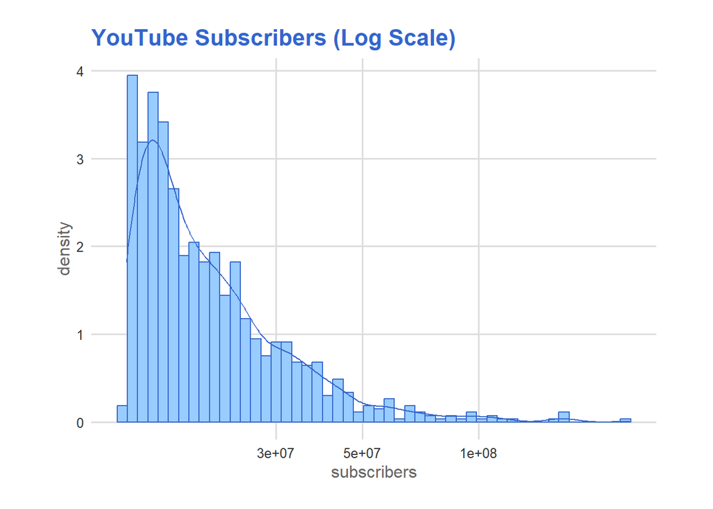

```r
p1 <- ggplot(data = youtube_data, mapping = aes(x = subscribers)) +
  geom_histogram(aes(y = after_stat(density)), bins = 50, fill = "#99CCFF", color = "#3366CC") +
  geom_density(color = "#3366CC") +
  scale_x_continuous(trans = 'log10') +
  ggtitle("YouTube Subscribers (Log Scale)") +
  custom_youtube_theme()
print(p1)
```

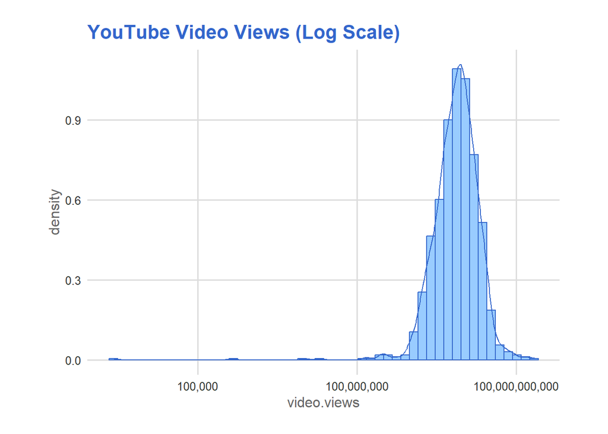

```r
p2 <- ggplot(data = youtube_data, mapping = aes(x = subscribers)) +
  geom_histogram(aes(y = after_stat(density)), bins = 100, fill = "#99CCFF", color = "#3366CC") +
  geom_density(color = "#3366CC") +
  coord_cartesian(xlim = c(12300000, 50000000)) +
  ggtitle("YouTube Subscribers (12.3M to 50M)")

p3 <- ggplot(data = youtube_data, mapping = aes(x = video.views)) +
  geom_histogram(aes(y = after_stat(density)), bins = 50, fill = "#99CCFF", color = "#3366CC") +
  geom_density(color = "#3366CC") +
  scale_x_continuous(trans = 'log10', labels = scales::comma) +
  ggtitle("YouTube Video Views (Log Scale)") +
  custom_youtube_theme()
print(p3)
```

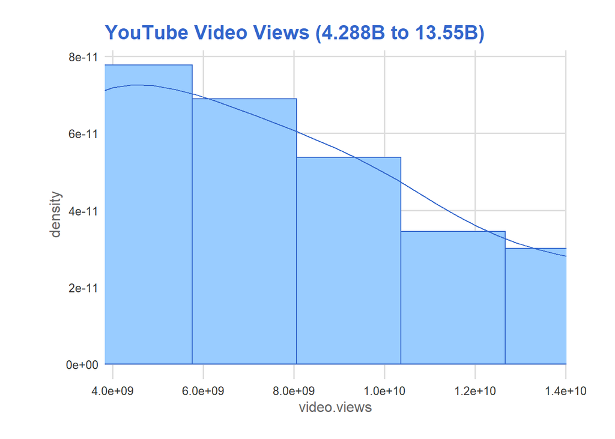

```r
p4 <- ggplot(data = youtube_data, mapping = aes(x = video.views)) +
  geom_histogram(aes(y = after_stat(density)), bins = 100, fill = "#99CCFF", color = "#3366CC") +
  geom_density(color = "#3366CC") +
  coord_cartesian(xlim = c(4.288e+09, 1.355e+10)) +
  ggtitle("YouTube Video Views (4.288B to 13.55B)") +
  custom_youtube_theme()
print(p4)
```

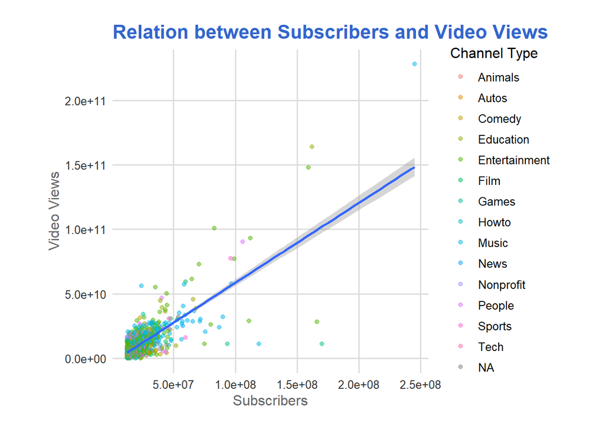

```r
p5 <- ggplot(youtube_data, aes(x=subscribers, y=video.views)) +
  geom_point(aes(color=channel_type), alpha=0.5) +
  geom_smooth(method=lm) +
  labs(title="Relation between Subscribers and Video Views",
       x="Subscribers", y="Video Views", color="Channel Type") +
  custom_youtube_theme()
print(p5)
```

```r
cor.test(youtube_data$subscribers, youtube_data$video.views, method="pearson")
```

```
##
##  Pearson's product-moment correlation
##
## data:  youtube_data$subscribers and youtube_data$video.views
## t = 38.018, df = 993, p-value < 2.2e-16
## alternative hypothesis: true correlation is not equal to 0
## 95 percent confidence interval:
##  0.7433282 0.7940631
## sample estimates:
##       cor
## 0.7699095
```

On the YouTube platform, there’s a significant positive correlation between the number of subscribers and video views, with a Pearson correlation coefficient of 0.7699. This suggests that as a channel’s subscriber count rises, there’s a high likelihood that its video views will also increase. Moreover, from the scatter plot, it appears that this relationship is consistent across different types of channels, indicated by varying colors. When smoothed with a linear model, we observe a linear increase in the predicted video views as the subscriber count goes up. However, there are also some ‘outliers’, channels with relatively high subscriber counts but fewer video views, or vice versa. This discrepancy might be due to certain channels having one or two viral videos that garner a significant number of views, but without a corresponding increase in the channel’s overall subscribers.

## 4.2 Analyzing Relationship between Subscribers and Country

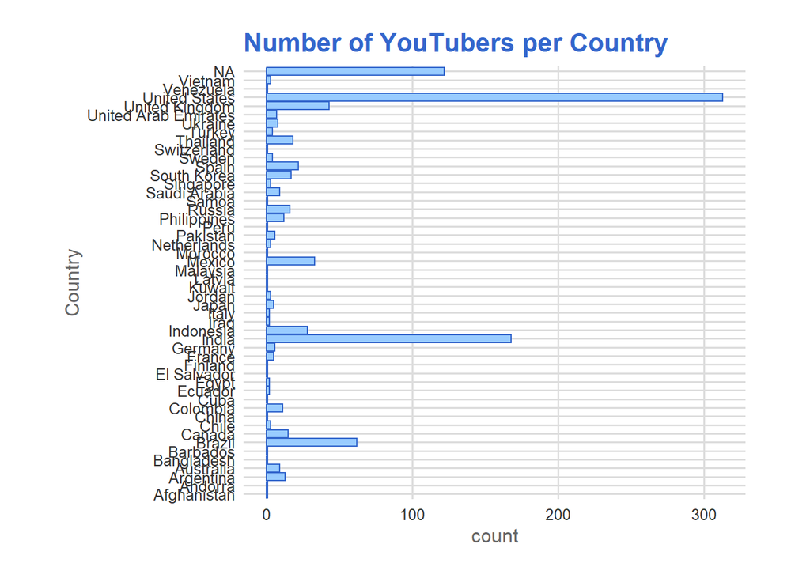

```r
p6 <- ggplot(data = youtube_data, mapping = aes(x = Country)) +
  geom_bar(fill = "#99CCFF", color = "#3366CC") +
  ggtitle("Number of YouTubers per Country") +
  coord_flip()+
  custom_youtube_theme()
print(p6)
```

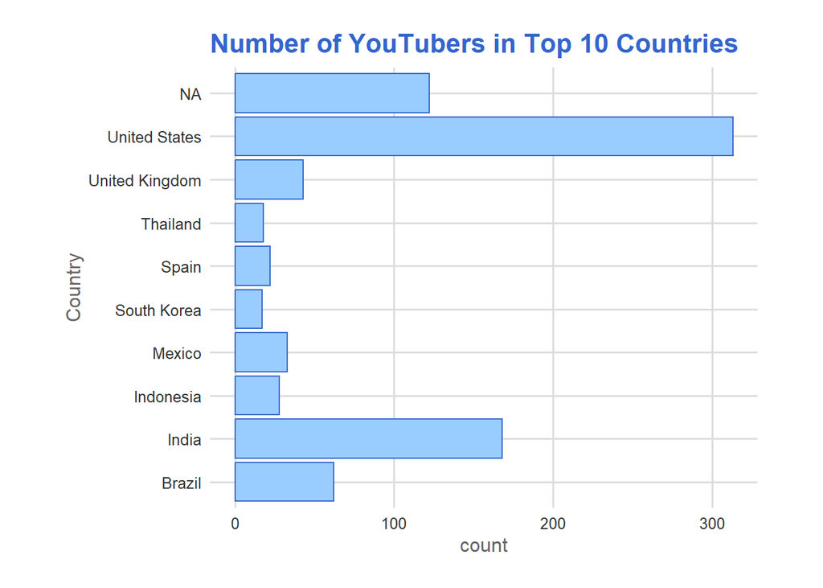

```r
top_countries <- youtube_data %>%
  count(Country) %>%
  arrange(-n) %>%
  head(10)

filtered_data <- youtube_data %>%
  filter(Country %in% top_countries$Country)

p7 <- ggplot(data = filtered_data, mapping = aes(x = Country)) +
  geom_bar(fill = "#99CCFF", color = "#3366CC") +
  ggtitle("Number of YouTubers in Top 10 Countries") +
  coord_flip()+
  custom_youtube_theme()
print(p7)
```

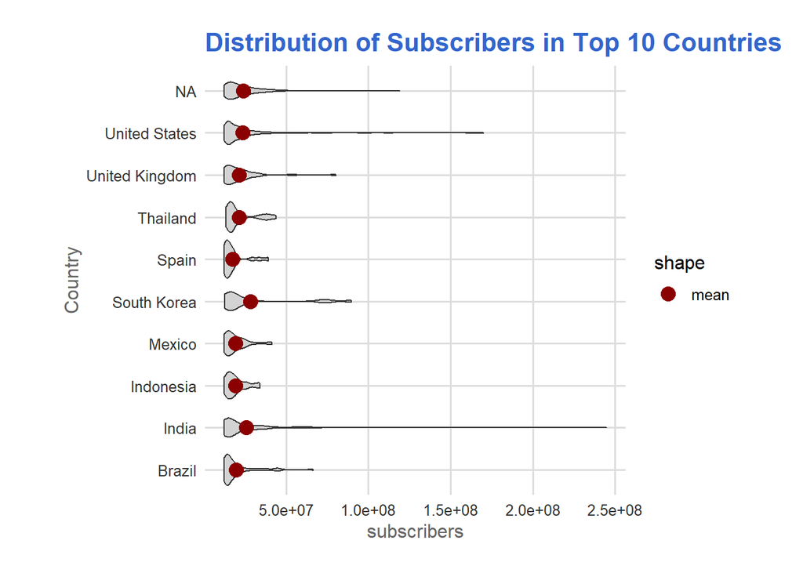

```r
gd <- filtered_data %>%
  group_by(Country) %>%
  summarise(average_subscribers = mean(subscribers, na.rm = T))

p8 <- ggplot(data = filtered_data,
             mapping = aes(y = subscribers, x = Country))+
  geom_violin(fill ='lightgray')+
  geom_point(data = gd, aes(y = average_subscribers, shape='mean'), color='darkred', size=4)+
  ggtitle("Distribution of Subscribers in Top 10 Countries") +
  coord_flip()+
  custom_youtube_theme()
print(p8)
```

From the “Number of YouTubers per Country” chart, it’s evident that there’s a significant variance in the number of YouTubers across countries. Some countries have a notably higher count of YouTubers than others.

## 4.3 Analyzing Relationship between Earning and video.views

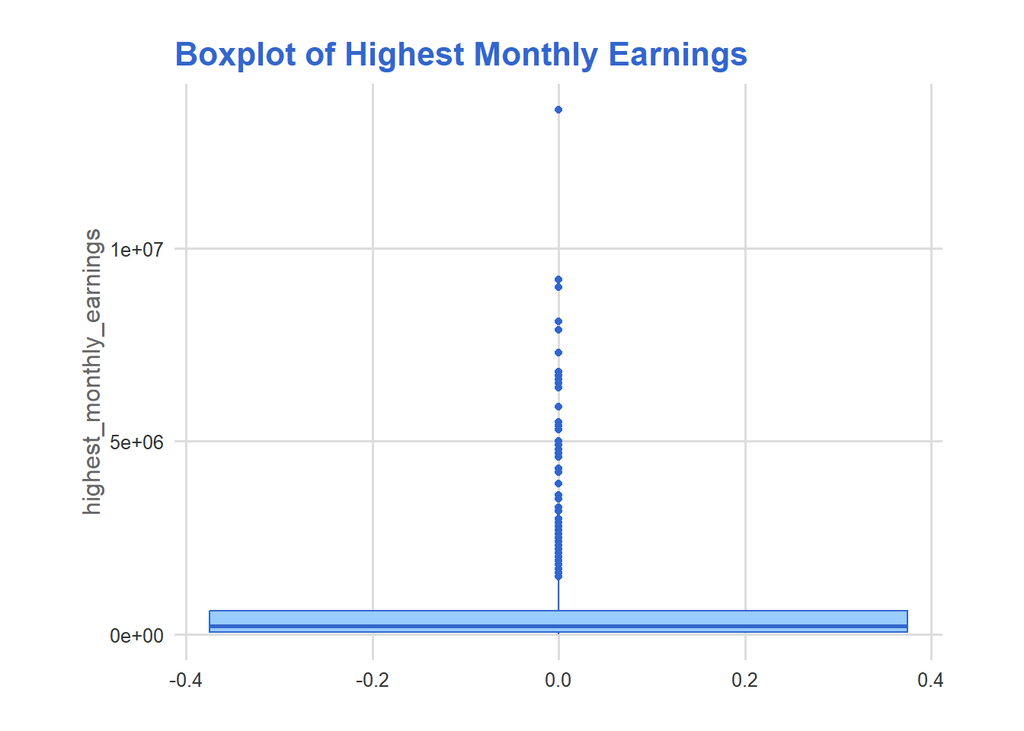

```r
p10 <- ggplot(data = youtube_data, mapping = aes(y = highest_monthly_earnings)) +
  geom_boxplot(fill = "#99CCFF", color = "#3366CC") +
  ggtitle("Boxplot of Highest Monthly Earnings") +
  custom_youtube_theme()
print(p10)
```

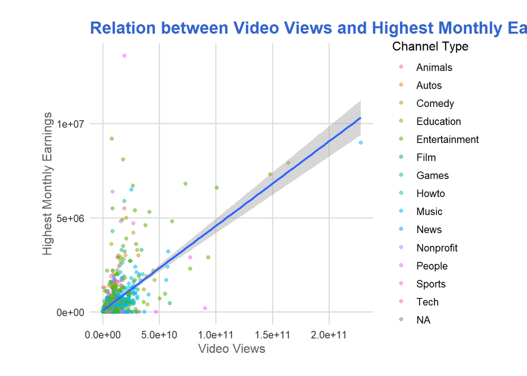

```r
p11 <- ggplot(youtube_data, aes(x=video.views, y=highest_monthly_earnings)) +
  geom_point(aes(color=channel_type), alpha=0.5) +
  geom_smooth(method=lm) + # 添加线性回归线
  labs(title="Relation between Video Views and Highest Monthly Earnings",
       x="Video Views", y="Highest Monthly Earnings", color="Channel Type") +
  custom_youtube_theme()
print(p11)
```

```r
cor_result <- cor.test(youtube_data$video.views, youtube_data$highest_monthly_earnings, method="pearson")
```

“Pearson Correlation Coefficient Value: The ‘cor’ value is 0.5495619, indicating a moderate positive linear relationship between video.views and highest_monthly_earnings. This means that as video views increase, the highest monthly earnings of a YouTuber tend to increase as well. Significance Level: The p-value is less than 2.2e-16. This is an extremely small p-value, far below typical significance levels (like 0.05). This suggests that the association we observe in the data is statistically significant and is unlikely to have occurred by random chance. Based on the above analysis, we can conclude that, within the provided YouTube data, there’s a significant moderate positive linear relationship between video views and a YouTuber’s highest monthly earnings. This might suggest that more video views could lead to higher monthly earnings

## 4.4 Analyzing Relationship between created_year and Subscribers

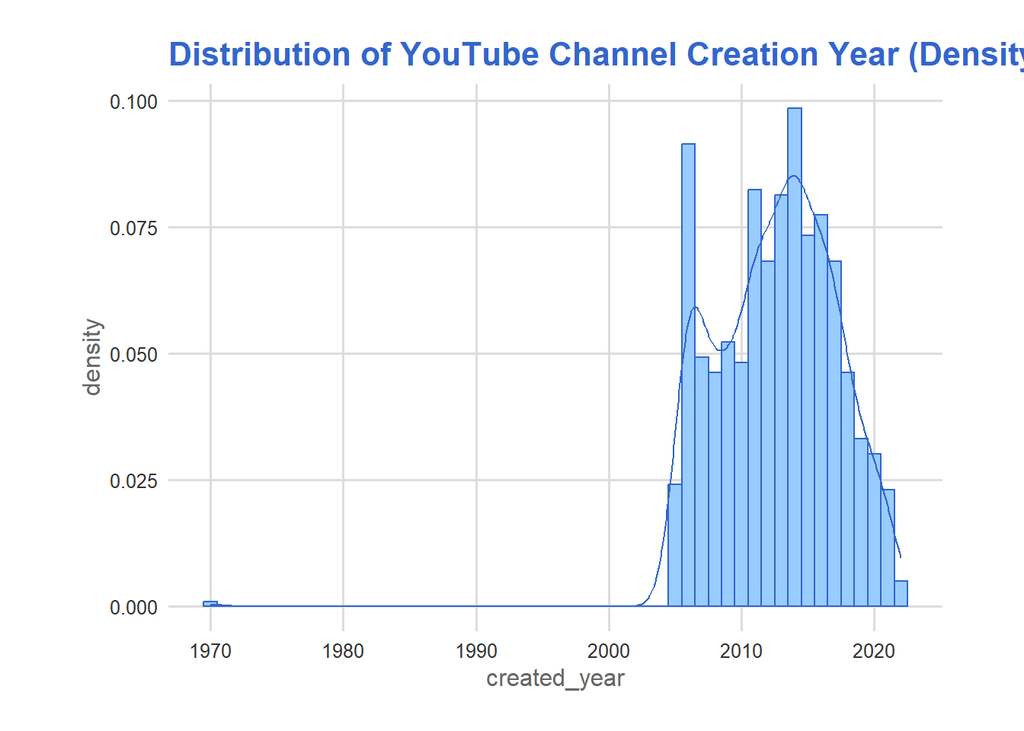

```r
p12 <- ggplot(data = youtube_data, mapping = aes(x = created_year)) +
  geom_histogram(aes(y = after_stat(density)), binwidth=1, fill = "#99CCFF", color = "#3366CC") +
  geom_density(color = "#3366CC") +
  ggtitle("Distribution of YouTube Channel Creation Year (Density)") +
  custom_youtube_theme()
print(p12)
```

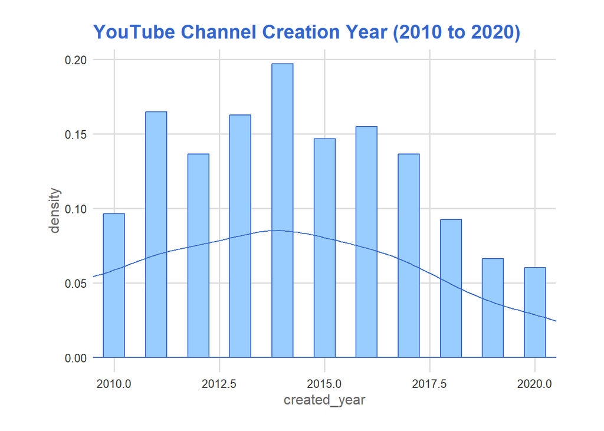

```r
p13 <- ggplot(data = youtube_data, mapping = aes(x = created_year)) +
  geom_histogram(aes(y = after_stat(density)), binwidth=0.5, fill = "#99CCFF", color = "#3366CC") +
  geom_density(color = "#3366CC") +
  coord_cartesian(xlim = c(2010, 2020)) +
  ggtitle("YouTube Channel Creation Year (2010 to 2020)") +
  custom_youtube_theme()
print(p13)
```

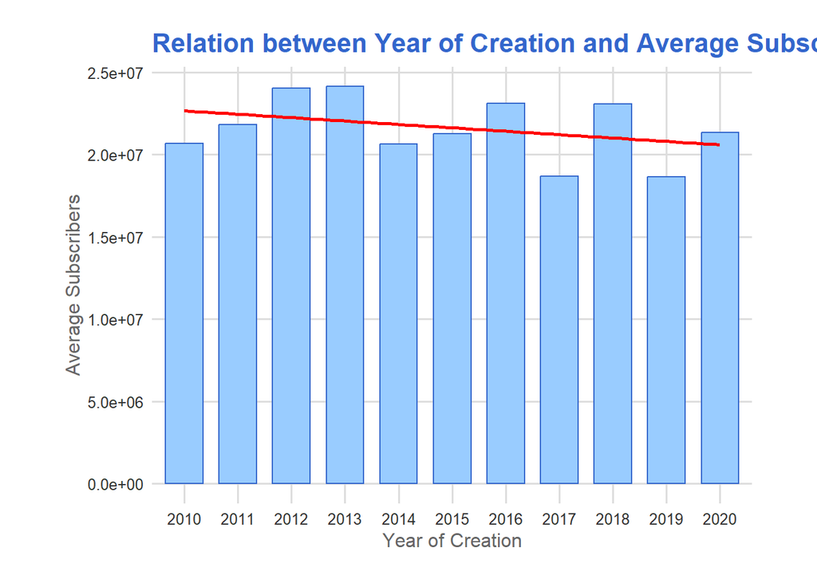

```r
youtube_data_filtered <- youtube_data[youtube_data$created_year >= 2010 & youtube_data$created_year <= 2020,]

p14 <- ggplot(data = youtube_data_filtered, aes(x = factor(created_year), y = subscribers)) +
  geom_bar(stat = "summary", fun = mean, fill = "#99CCFF", color = "#3366CC", width = 0.7) +
  geom_smooth(aes(group = 1), method = "lm", color = "red", se = FALSE) +
  labs(title = "Relation between Year of Creation and Average Subscribers (2010-2020)",
       x = "Year of Creation", y = "Average Subscribers") +
  custom_youtube_theme()
print(p14)
```

```r
cor_result <- cor.test(youtube_data_filtered$created_year, youtube_data_filtered$subscribers, method = "pearson")
```

On the YouTube platform, we further explored the relationship between the year a channel was created and its subscriber count. From the Pearson correlation coefficient analysis, it’s evident that there’s a negative correlation between the channel’s creation year and the number of subscribers, with a correlation coefficient of -0.1419. Although this relationship is relatively weak, it’s statistically significant as the p-value is well below 0.05.

It’s worth noting that from our previous analysis, we determined that there’s a significant positive correlation between subscriber count and video views. Now, recognizing a negative correlation between the channel’s creation year and subscriber count implies that newer channels might need to exert more effort to attract viewers and increase video views.